# Taxi 101

## Pricing engine w.r.t. market

For pricing, I have approached the problem with the market distribution. For pricing I am building a regression model (using XGBoost) with input features as trip time, pickup location and dropoff location. If developed as an API, rest of the feature engine functions can be written separately. But for this demo, I am sampling data from the already existed data not used for training as it is already feature engineered.

### Coordinate to Area

This helper function is written keeping is mind that in practice that the user will just input the location, there will be API running in the background to get the coordinates and based on the coordinates, we will obtain community area for pickup and drop off location. For this I am using 'KNeighborsClassifier'.

So may ask why?. The answer is because the area number is used as one of the input feature for regression model.

```
As as an example for Corrdinates [-87.633308, 41.899602] the area obtained is 8
```

### Analyzing the Input Feature - Correlation

As you can see the input feature used for regression and it correlation. Distance from pickup and dropoff has the higher correlation, followed by pickup area and etc. Since this data is available when booking a taxi, same is used as a input features for regression model.

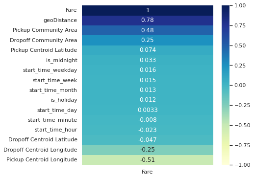

### Price Engine Training

For price engine training, XGBoost is selected for training regression model.

```
rmse = 6.196053332822338
mae = 3.138344272920899
```

### Price is right - Running Price Engine on Sample data from Test Set

As mentioned above, after user select location and time, there will some back-end process to run and obtain all feature engineered input. For this demo I am sampling data from test set which is already cleaned and processed. Below I am running few samples with different multiplier. multiplier in this case is for either upsurge demand or downtrend demand.

```
Sample Trip #1
```

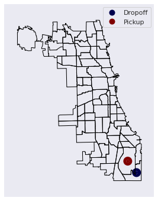

```
Actual Price = 1072993    31.0
Name: Fare, dtype: float64
Trip Fare as per price Engine  = 25.9
```

```
Sample Trip #2
```

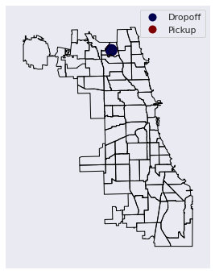

```
Actual Price = 1706737    7.0
Name: Fare, dtype: float64
The Multiplier for the current time is :0.8
Trip Fare as per price Engine  = 8.24
```

```
Sample Trip #3
```

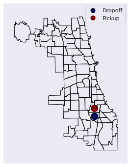

```
Actual Price = 815792    6.75
Name: Fare, dtype: float64
The Multiplier for the current time is :1.2
Trip Fare as per price Engine  = 21.0
```

## Market analysis as a Use cases for a taxi launch - Experimental

Note: This is still experimental.

For Taxi Launch, I am trying to see the optimized revenue of the market in terms number of trips per price segment i.e. low-price, medium-price and high-price per taxi.

The same methodology can be extended to trip per community area as well with minor changes in problem formulation.

### With upper bound as Q3 Quantile

Let's run the market analysis with upper bound as Q3 quantile. The plot comprise of three things, revenue distribution with the existing distribution of the trips per segment, the current revenue and the max optimized value with upper bound as Q3 Quantile.

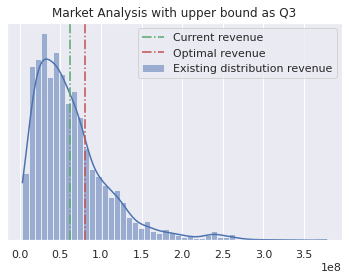

```
Current Revenue $61,647,994.51
Optimal Revenue with upper bound as Q3 Revenue $80,287,038.00
```

### With upper bound as Mean Value

Market analysis with upper bound as Mean Value. The plot comprise of three things, revenue distribution with the existing distribution of the trips per segment, the current revenue and the max optimized value with upper bound as Mean Value.

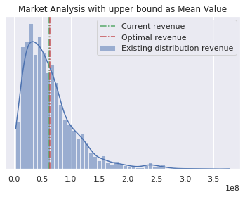

```
Current Revenue $61,647,994.51
Optimal Revenue with upper bound as Mean Revenue $62,825,022.00
```

### With upper bound as Median Value

Market analysis with upper bound as Median Value. The plot comprise of three things, revenue distribution with the existing distribution of the trips per segment, the current revenue and the max optimized value with upper bound as Median Value.

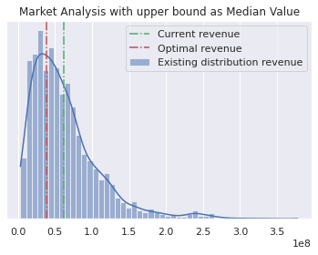

```
Current Revenue $61,647,994.51
Optimal Revenue with upper bound as Median Revenue $38,931,516.00
```

### With Taxi Market share of 10% and upper bound as Q3 Quantile

Market analysis with Taxi Market share of 10% and upper bound as Q3 Quantile. The plot comprise of three things, revenue distribution with the existing distribution of the trips per segment and the max optimized value with market share of 10% along with upper bound as Q3 Quantile Value.

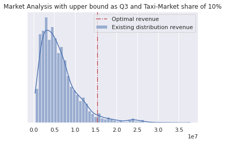

```
Optimal Revenue with upper bound as Q3 Revenue and Taxi-Market share of 10% : $15,439,815.00
```

### With Taxi Market share of 10% and upper bound as Mean

Market analysis with Taxi Market share of 10% and upper bound as Mean value. The plot comprise of three things, revenue distribution with the existing distribution of the trips per segment and the max optimized value with market share of 10% along with upper bound as Mean Value.

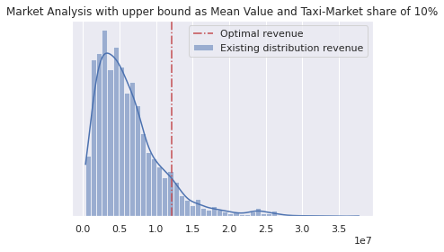

```
Optimal Revenue with upper bound as Mean Revenue and Taxi-Market share of 10% : $12,081,735.00
```

### With Taxi Market share of 10% and upper bound as Median

Market analysis with Taxi Market share of 10% and upper bound as Median Quantile. The plot comprise of three things, revenue distribution with the existing distribution of the trips per segment and the max optimized value with market share of 10% along with upper bound as Median Value.

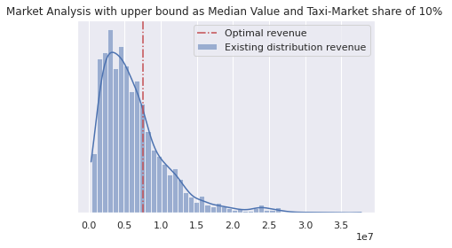

```
Optimal Revenue with upper bound as Median Revenue and Taxi-Market share of 10% : $7,486,830.00
```